# Computing the ISTH disseminated intravascular coagulation score

Here we use [Phea](https://github.com/fabkury/phea) to compute the overt disseminated intravascular coagulation score produced by the International Society for Thrombosis and Hemostasis:

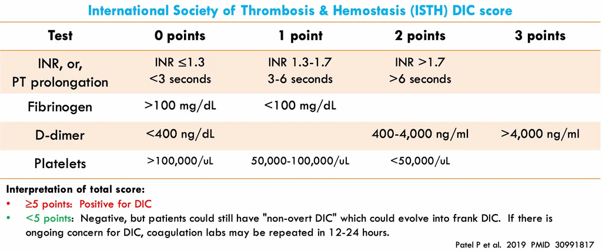

For this vignette, we will assume you have a SQL server at `localhost`, with patient data in OMOP Common Data Model v5.4 format, inside schema `cdm_new_york3`.

This vignette was produced using synthetic data generated by [Synthea Patient Generator](https://synthetichealth.github.io/synthea/) and ETL’d into OMOP CDM v5.4 by ETL-Synthea. Lots of thanks to both projects!

## Setup Phea

First we connect to the server. Calling `setup_phea()` is optional, but it enables the convenience functions `slqt()` and `sql0()`.

```r
library(phea)
suppressPackageStartupMessages(library(dplyr))

# Connect to SQL server.
dbcon <- DBI::dbConnect(
    RPostgres::Postgres(),
    host = 'localhost', port = 8765, dbname = 'fort',
    user = cred$pg$user, password = cred$pg$pass)

# Provide the connection to Phea so we can use the sqlt() and sql0() shorthands.
setup_phea(dbcon, 'cdm_new_york3')
```

## Create components

Let component `d_dimer` be records from table `MEASUREMENT` where `measurement_concept_id` is equal to `3051714`.

```r
# LOINC code 48065-7 Fibrin D-dimer FEU [Mass/volume] in Platelet poor plasma
# OMOP CDM concept ID 3051714
d_dimer <- sqlt(measurement) |>
  filter(measurement_concept_id == 3051714) |>
  make_component(
    .pid = person_id,
    .ts = measurement_datetime)
```

Let component `inr` be records from table `MEASUREMENT` where `measurement_concept_id` is equal to `3022217`.

```r
# LOINC code 6301-6 INR in Platelet poor plasma by Coagulation assay
# OMOP CDM concept ID 3022217
inr <- sqlt(measurement) |>
  filter(measurement_concept_id == 3022217) |>
  make_component(
    .pid = person_id,
    .ts = measurement_datetime)
```

Let component `platelet` be records from table `MEASUREMENT` where `measurement_concept_id` is equal to `3024929`.

```r
# LOINC code 777-3 Platelets [#/volume] in Blood by Automated count
# OMOP CDM concept ID 3024929
platelet <- sqlt(measurement) |>
  filter(measurement_concept_id == 3024929) |>
  make_component(
    .pid = person_id,
    .ts = measurement_datetime)
```

## Calculate the phenotype

The phenotype logic can be regarded as having two steps:

1. first you interpret the values, i.e. compare to their thresholds, e.g. `is platelet count under 50,000?`
2. then you add the points to produce the final answer `yes there is overt DIC` or `no there is no overt DIC`.

We will accomplish that using a sequence of formulas.

```r
dic_score <- calculate_formula(
  components = list(
    d_dimer = d_dimer,
    inr = inr,
    platelet = platelet),
  fml = list(
    d_dimer_points = 'case
      when d_dimer_value_as_number >= 4 then 3
      when d_dimer_value_as_number >= 0.4 then 2
      when d_dimer_value_as_number < 0.4 then 0
      else null end',
    inr_points = 'case
      when inr_value_as_number <= 1.2 then 0
      when inr_value_as_number <= 1.7 then 1
      when inr_value_as_number > 1.7 then 2
      else null end',
    platelet_points = 'case
      when platelet_value_as_number < 50 then 2
      when platelet_value_as_number <= 100 then 1
      when platelet_value_as_number > 100 then 0
      else 0 end',
    isth_score = 'd_dimer_points + inr_points + platelet_points',
    overt_dic = 'case when isth_score >= 5 then 1 else 0 end'),
  window = '2 days')
```

## Plot the phenotype result

```r
if(!exists('pids'))
  pids <- dic_score |>
    select(pid) |>
    distinct() |>
    pull()
```

```r
phea_plot(dic_score, sample(pids, 1))
```

[interactive chart not shown]